# Untitled

## Introduction and Theoretical Framework

##### The Montreal Street Gang Network, originally constructed and analysed by [Katine Descormiers and Carlos Morselli](https://journals.sagepub.com/doi/10.1177/1057567711418501) (2011) has also been the focus of further studies. These have demonstrated that when looking at the relationships between different gangs in the city, shared characteristics or attributes do not have a significant relationship in affecting the probability of tie formation ([Wallin, 2021](https://jameshollway.com/courses/ison/wallin_post)). This is interesting, as other studies on gang networks have pointed to a lack of structural analysis into the role of clustering, or triad closures, which leads to an overestimation)) of the role of homophily ([Grund & Densely, 2015](https://journals.sagepub.com/doi/abs/10.1177/1043986214553377)). However, as this network homophily does not seem to play a statistically significant role, the question remains on the role of clustering, meaning if the gangs are connected to each other and each is also connected to a third gang forming a triad closure. Therefore, this investigation will deal with the following hypothesis:

##### -H1: Gangs with similar attributes, in this case ethnicity, territories, and allegiances, are more likely to form a relationship with each other. (based on [Wallin, 2021](https://jameshollway.com/courses/ison/wallin_post)).

##### -H2: Gangs’ relationships are formed through clustering.

## Data Overview and Visualisation

##### The data found in this network was gathered from interviews with gang members in Montreal in 2007, which at the time had identified 35 active gangs in the city ([Descormiers & Morselli, 2011](https://journals.sagepub.com/doi/10.1177/1057567711418501)). The data also included the attributes on where they operate within Montreal (Downtown, East, West), the ethnicities of the gangs (Afro-Canadian, Asian, Caucasian, Hispanic, Mixed), their allegiance to bigger groups of gangs present in the city (Bloods, Crips, or Other). This network is not directed or weighted, meaning that ties represent the relationships between gangs as reported by the gang members during the focus groups and interviews, and therefore do not indicate if the relationships are positive or negative, or any type of hierarchical or influence/power dynamics present in this context. In order to best visualise the network for the purpose of this investigation, the choice was to use a 3D visualisation of the network (below) in which one is to select specific nodes and see their edges.

[interactive chart not shown]

## Modelling

### Results

ERGM results table

|  | Model1 |
| --- | --- |
| edges | -3.93*** |
|  | (0.34) |
| nodematch.Ethnicity | -0.35 |
|  | (0.29) |
| nodematch.Territories | 0.20 |
|  | (0.22) |
| nodematch.Allegiances | -0.16 |
|  | (0.31) |
| gwesp.fixed.0.5 | 1.34*** |
|  | (0.20) |
| AIC | 403.52 |
| BIC | 425.46 |
| Log Likelihood | -196.76 |

***p < 0.01; **p < 0.05; *p < 0.1

##### In terms of H1, we see that we cannot reject the null hypothesis, as there in no attribute has a significant effect on the formation of relationships between the gangs in the network, which is not surprising as it had already between demonstrated by previous investigations ([Wallin, 2021](https://jameshollway.com/courses/ison/wallin_post)). Differently, however, in terms of H2, we can reject the null hypothesis as triad closures have a significant effect on relationship formation between gangs within this network.

## Markov Chain Monte Carlo (MCMC)

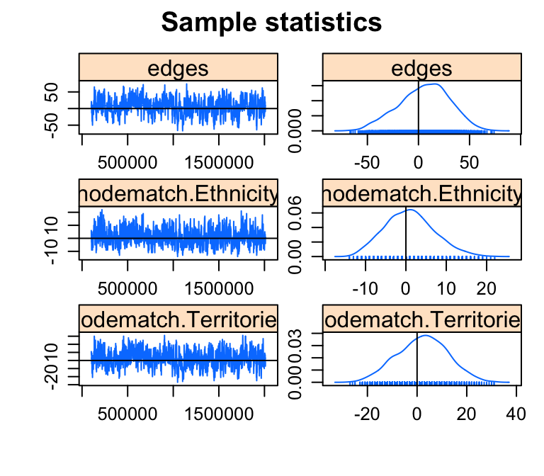

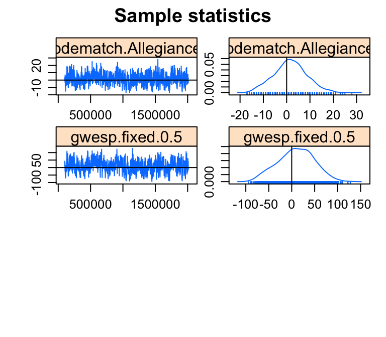

##### In general, the model converged well with 99% confidence in the 13th iteration of 60. This is further observed in the sample statistics above, which show mostly normal distribution. However, in some of them we see negative skewness (left-skewed), thus, making them asymmetrical distributions. This, though perhaps uncomfortable to the eye is not necessarily an issue, however, one could run a distribution test to identify the distribution of your data.

## Diagnostics: Goodness-of-fit (GOF)

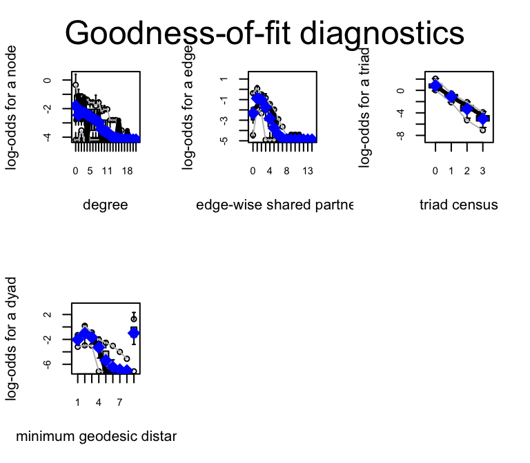

##### As observed in the plots above, the observed values are generally within the range of the simulated values, with some instances in which the values are overestimated or underestimated. On this, some fixes were attempted, however, to little effect. It is also important to keep in mind that there was some missing data in terms of the three attributes which might affect the goddess of fit of the present data and network.

## Conclusion

##### In conclusion, this investigation has, whilst connecting with the original authors and other studies, managed to confirm previous on homophily not being a factor for tie formation between the gangs within this network. We have also managed to connect with social networks literature, and demonstrate in fact, a structural factor, in this case clustering was better at explaining the formation of ties. This is interesting, and it further confirms general ideas about networks. It would be interesting to see how this network has evolved over time, and if these closures have remained the same or not. Furthermore, making this a directed network could bring additional insights.